# Barred Sand Bass, Southern California Recreational Fishery

### Recruitment Observations

#### Sampled Parameters

Histograms of 48 simulations of inter-annual variability in index observations (`Recsd`) , with vertical colored lines indicating 3 randomly drawn values used in other plots:

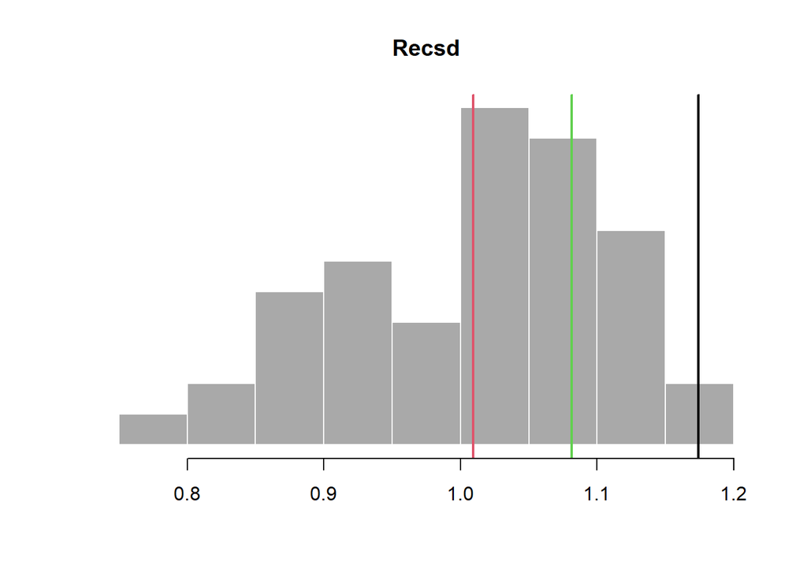

#### Time-Series

Timeseries plots of observeration error for recruitment:

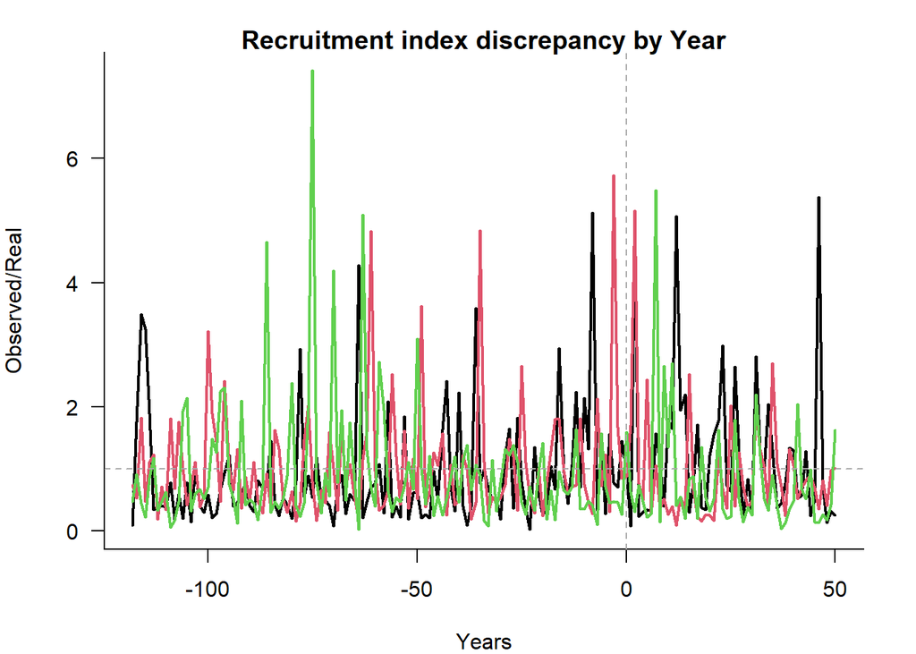

### Composition Observations

#### Sampled Parameters

Histograms of 48 simulations of catch-at-age effective sample size (`CAA_ESS`) and sample size (`CAA_nsamp`) and catch-at-length effective (`CAL_ESS`) and actual sample size (`CAL_nsamp`) with vertical colored lines indicating 3 randomly drawn values:

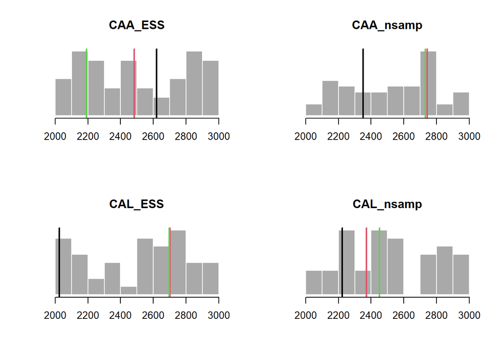

### Parameter Observations

#### Sampled Parameters

Histograms of 48 simulations of bias in observed natural mortality (`Mbias`), von Bertalanffy growth function parameters (`Linfbias`, `Kbias`, and `t0bias`), length-at-maturity (`lenMbias`), and bias in observed length at first capture (`LFCbias`) and first length at full capture (`LFSbias`) with vertical colored lines indicating 3 randomly drawn values:

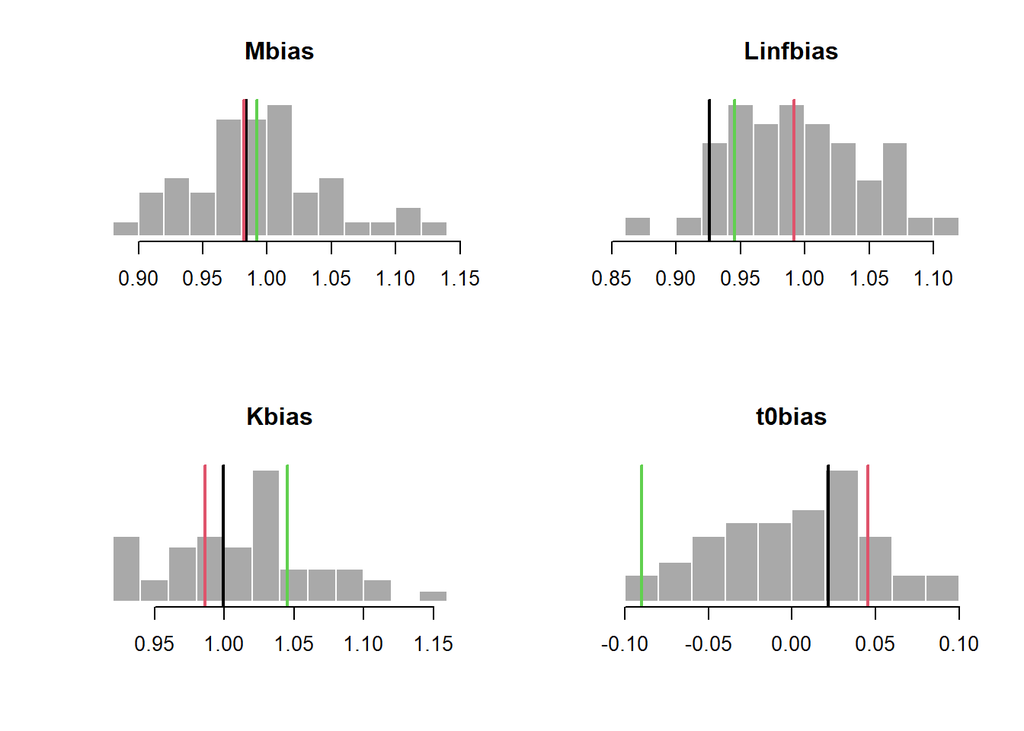

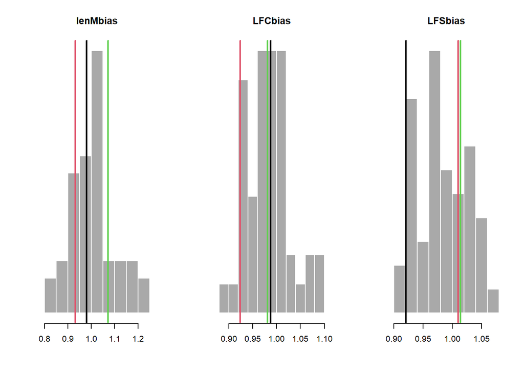

### Reference Point Observations

#### Sampled Parameters

Histograms of 48 simulations of bias in observed FMSY/M (`FMSY_Mbias`), BMSY/B0 (`BMSY_B0bias`), reference index (`Irefbias`), reference abundance (`Brefbias`) and reference catch (`Crefbias`), with vertical colored lines indicating 3 randomly drawn values:

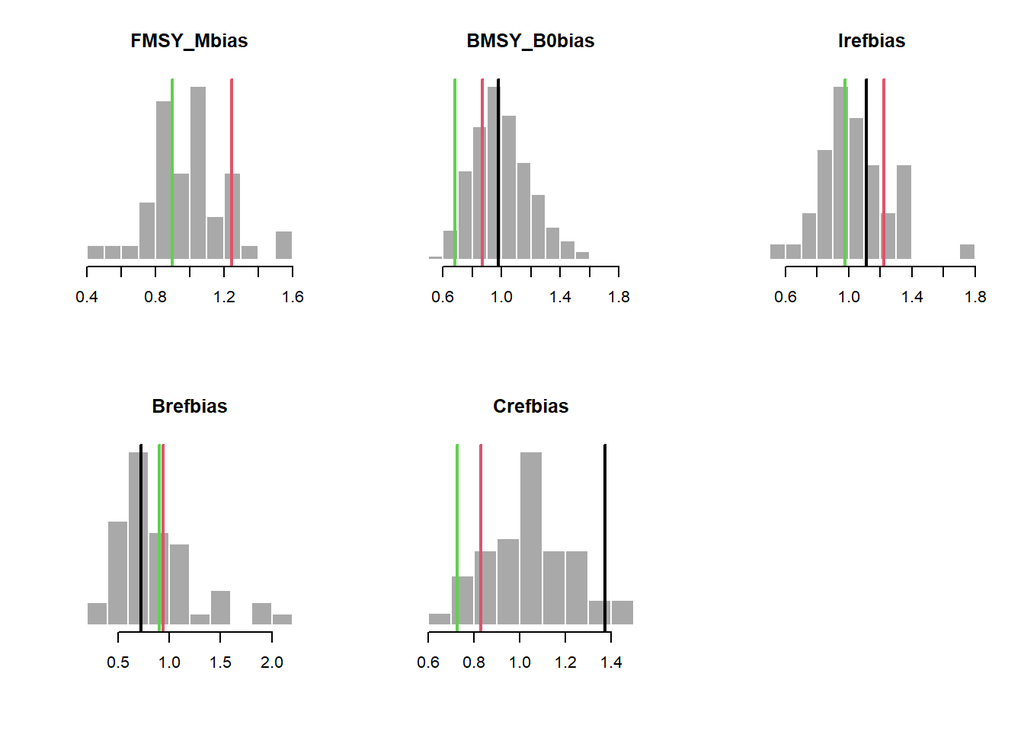

# Imp Parameters

### Output Control Implementation Error: TACFrac, TACSD

**TACFrac**: Mean fraction of recommended TAC that is actually taken. For each historical simulation a single value is drawn from a uniform distribution specified by the upper and lower bounds provided. This value is the mean TAC fraction obtained across all years of that simulation, and a yearly TAC frac is drawn from a log-normal distribution with the simulation mean and a coefficient of variation specified by the value of TACSD drawn for that simulation. If the value drawn is greater than 1 the amount of catch taken is greater than that recommended by the TAC, and if it is less than 1 the amount of catch taken is less than that recommended by the TAC. Positive real numbers.

Specified Value(s): 0.9, 1.1

Given the difficulties in estimating catch in a recreational fishery, as well as with implementing any type of catch limit, it was assumed that the actual catch would be within +/- 10% of the TAC.

**TACSD**: Log-normal coefficient of variation in the fraction of recommended TAC that is actually taken. For each historical simulation a single value is drawn from a uniform distribution specified by the upper and lower bounds provided. This value is used, along with the TACFrac drawn for that simulation, to create a log-normal distribution that yearly values specifying the actual amount of catch taken are drawn from. Positive real numbers.

Specified Value(s): 0, 0.05

### Effort Control Implementation Error: TAEFrac, TAESD

**TAEFrac**: Mean fraction of recommended TAE that is actually taken. For each historical simulation a single value is drawn from a uniform distribution specified by the upper and lower bounds provided. This value is the mean TAE fraction obtained across all years of that simulation, and a yearly TAE frac is drawn from a log-normal distribution with the simulation mean and a coefficient of variation specified by the value of TAESD drawn for that simulation. If the value drawn is greater than 1 the amount of effort employed is greater than that recommended by the TAE, and if it is less than 1 the amount of effort employed is less than that recommended by the TAE. Positive real numbers.

Specified Value(s): 0.9, 1.1

Given the difficulties in limiting effort it was assumed that the actual catch would be +/- 10% of the TAE.

**TAESD**: Log-normal coefficient of variation in the fraction of recommended TAE that is actually taken. For each historical simulation a single value is drawn from a uniform distribution specified by the upper and lower bounds provided. This value is used, along with the TAEFrac drawn for that simulation, to create a log-normal distribution that yearly values speciying the actual amount of efort employed are drawn from. Positive real numbers.

Specified Value(s): 0, 0.05

### Size Limit Control Implementation Error: SizeLimFrac, SizeLimSD

**SizeLimFrac**: Mean fraction of recommended size limit that is actually retained. For each historical simulation a single value is drawn from a uniform distribution specified by the upper and lower bounds provided. This value is the mean size limit fraction obtained across all years of that simulation, and a yearly size limit fraction is drawn from a log-normal distribution with the simulation mean and a coefficient of variation specified by the value of SizeLimSD drawn for that simulation. If the value drawn is greater than 1 the size of fish retained is greater than that recommended by the size limit, and if it is less than 1 the amount of size of fish retained is less than that recommended by the size limit. Positive real numbers.

Specified Value(s): 0.9, 0.95

Based on the large number of sublegal fish retained in recent years, it was assumed that the implemented size limit would be within 90-95% of the desired size limit.

**SizeLimSD**: Log-normal coefficient of variation in the fraction of recommended size limit that is actually retained. For each historical simulation a single value is drawn from a uniform distribution specified by the upper and lower bounds provided. This value is used, along with the SizeLimFrac drawn for that simulation, to create a log-normal distribution that yearly values speciying the actual fraction of the size limit retained are drawn from. Positive real numbers.

Specified Value(s): 0, 0

It was assumed that the implementation of the size limit would not change from year to year, and so this parameter was set to 0.

## Implementation Parameters

### TAC Implementation

#### Sampled Parameters

Histograms of 0 simulations of inter-annual variability in TAC implementation error (`TACSD`) and persistent bias in TAC implementation (`TACFrac`), with vertical colored lines indicating 3 randomly drawn values used in other plots:

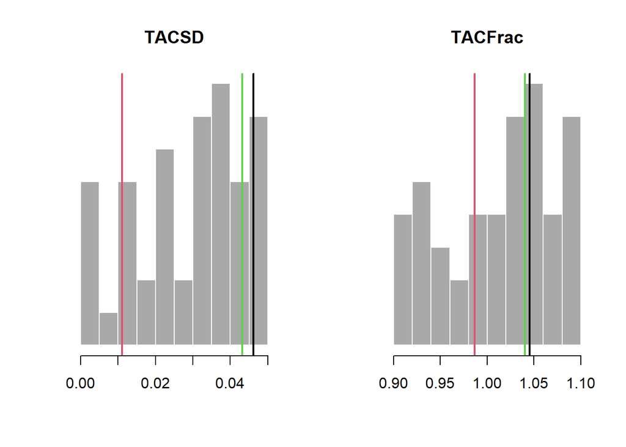

#### Time-Series

Time-series plots of 0 samples of TAC implementation error by year:

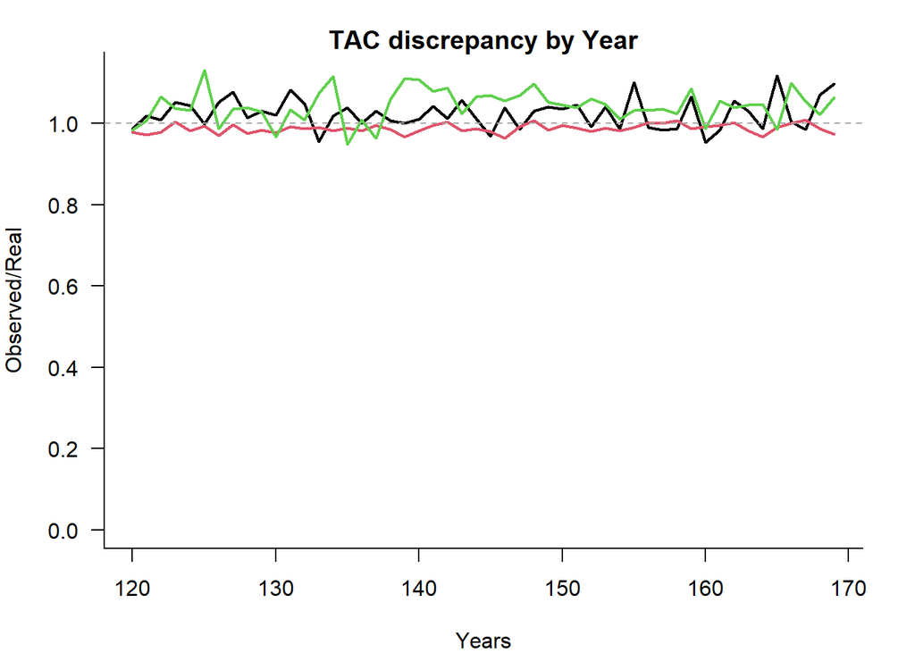

### TAE Implementation

#### Sampled Parameters

Histograms of 0 simulations of inter-annual variability in TAE implementation error (`TAESD`) and persistent bias in TAC implementation (`TAEFrac`), with vertical colored lines indicating 3 randomly drawn values used in other plots:

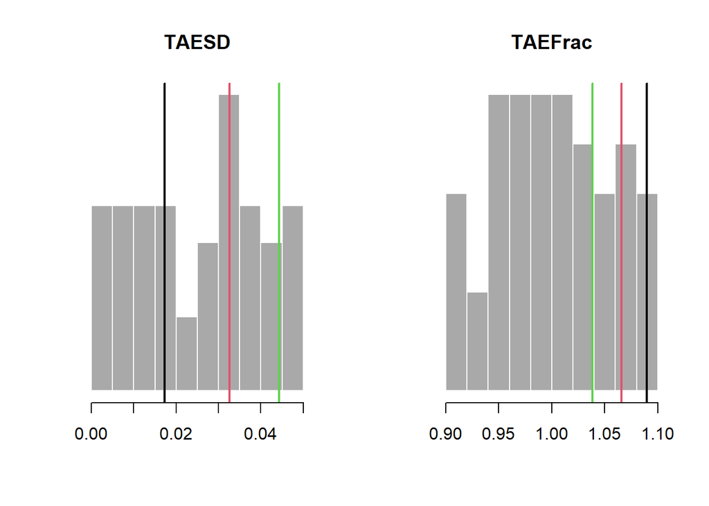

#### Time-Series

Time-series plots of 0 samples of TAE implementation error by year:

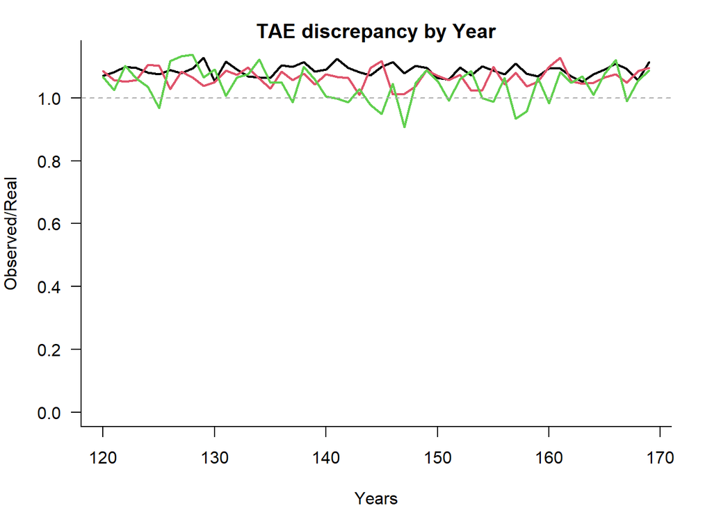

### Size Limit Implementation

#### Sampled Parameters

Histograms of 0 simulations of inter-annual variability in size limit implementation error (`SizeLimSD`) and persistent bias in size limit implementation (`SizeLimFrac`), with vertical colored lines indicating 3 randomly drawn values used in other plots:

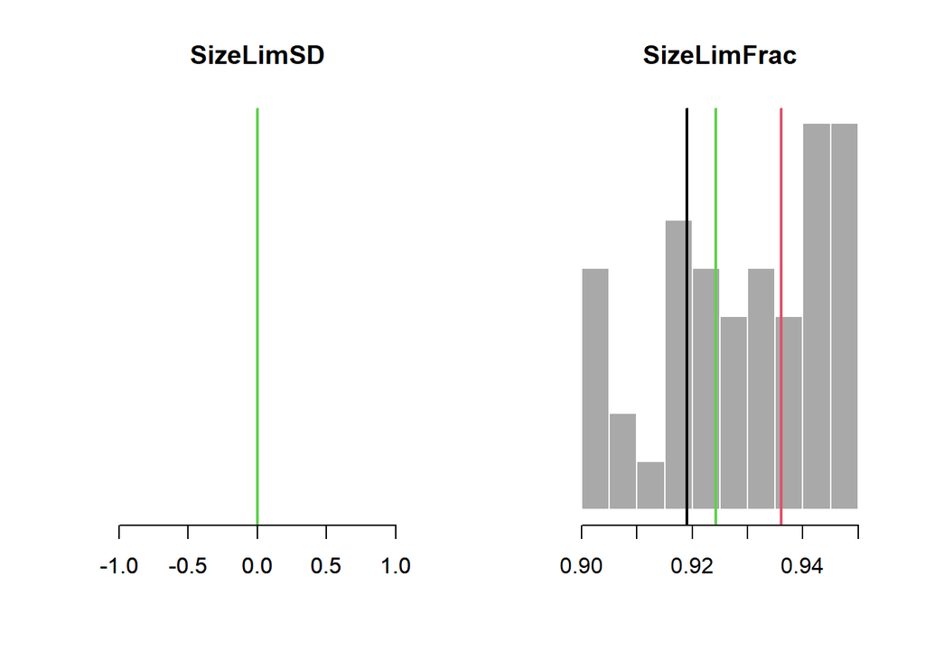

#### Time-Series

Time-series plots of 0 samples of Size Limit implementation error by year:

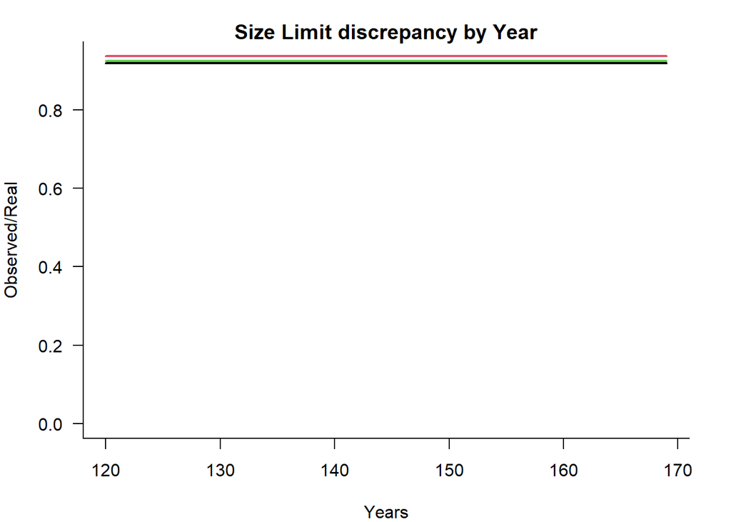

# Historical Simulation Plots

## Historical Time-Series

### Spawning Biomass

#### Depletion

Time-series plots of SB/SB0:

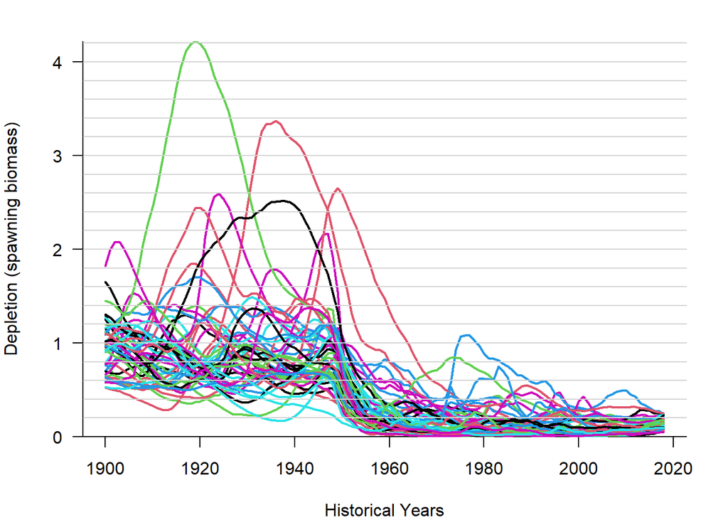

#### Absolute

Time-series plots of absolute SB:

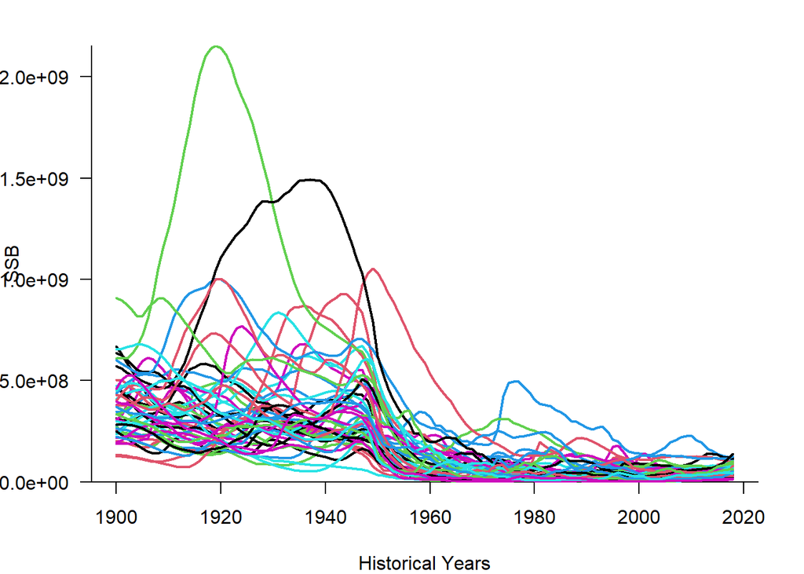

### Vulnerable Biomass

#### Depletion

Time-series plots of VB/VB0:

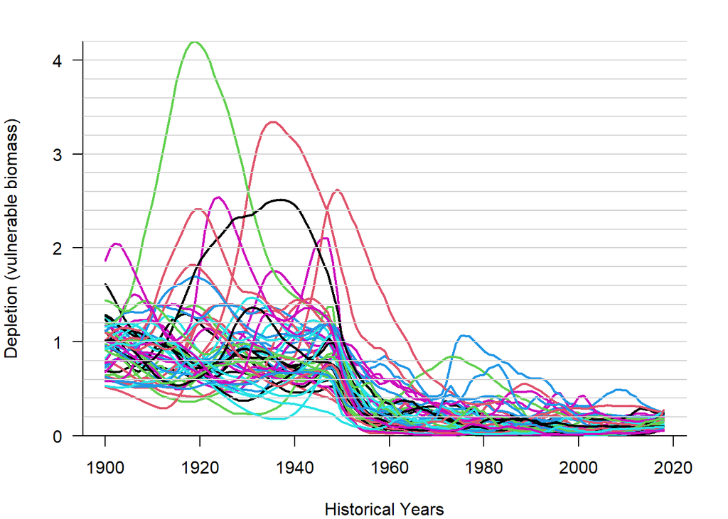

#### Absolute

Time-series plots of absolute VB:

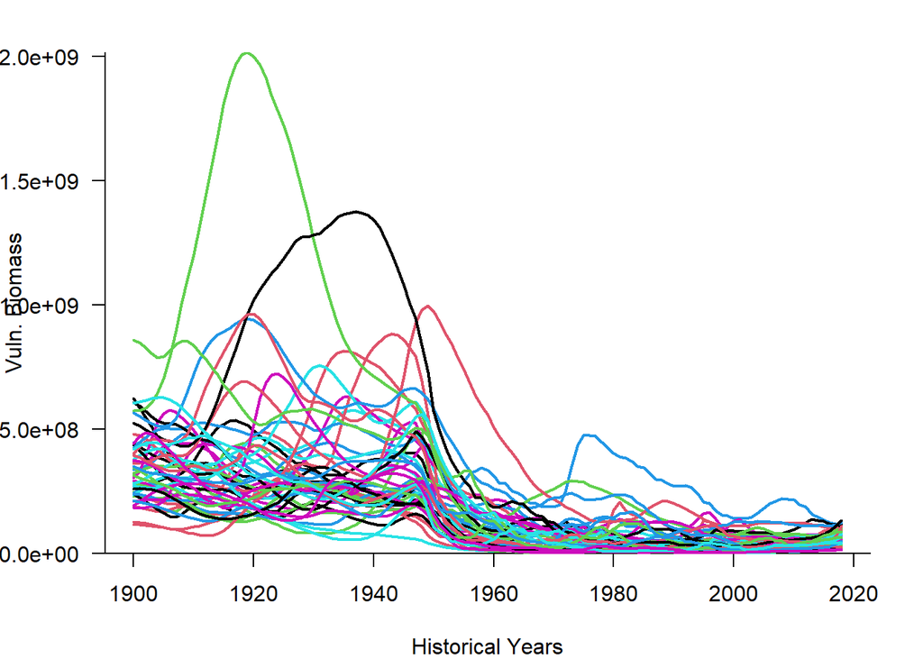

### Total Biomass

#### Depletion

Time-series plots of B/B0:

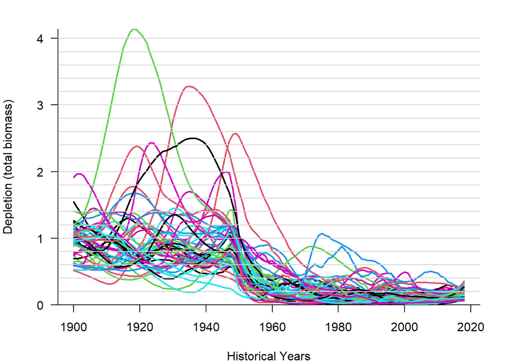

#### Absolute

Time-series plots of absolute B:

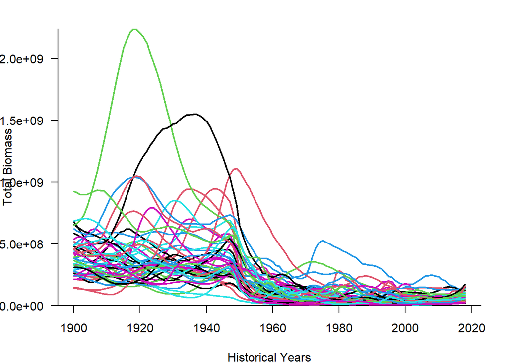

### Recruitment

#### Relative

Time-series plot of recruitment relative to R0:

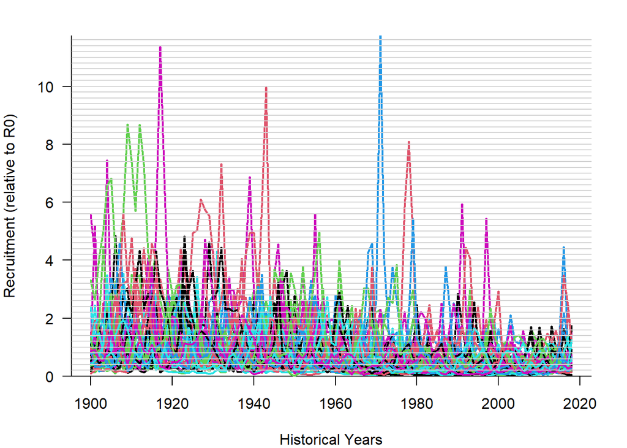

#### Absolute

Time-series plot of absolute recruitment:

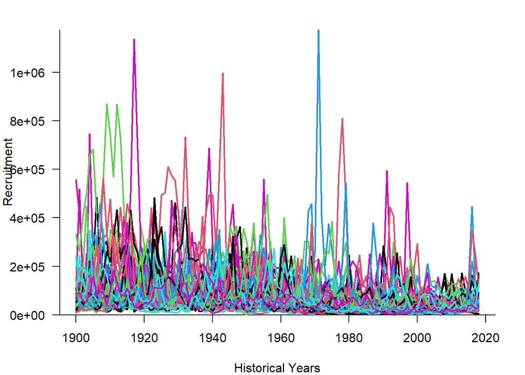

### Catch

#### Relative

Time-series of catch relative to the current year:

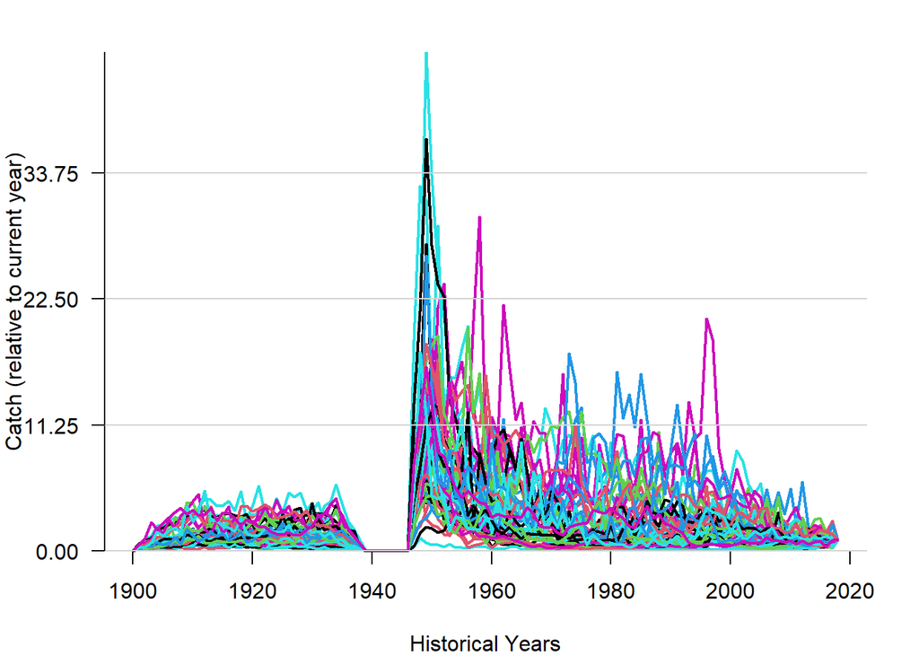

#### Absolute

Time-series of absolute catch:

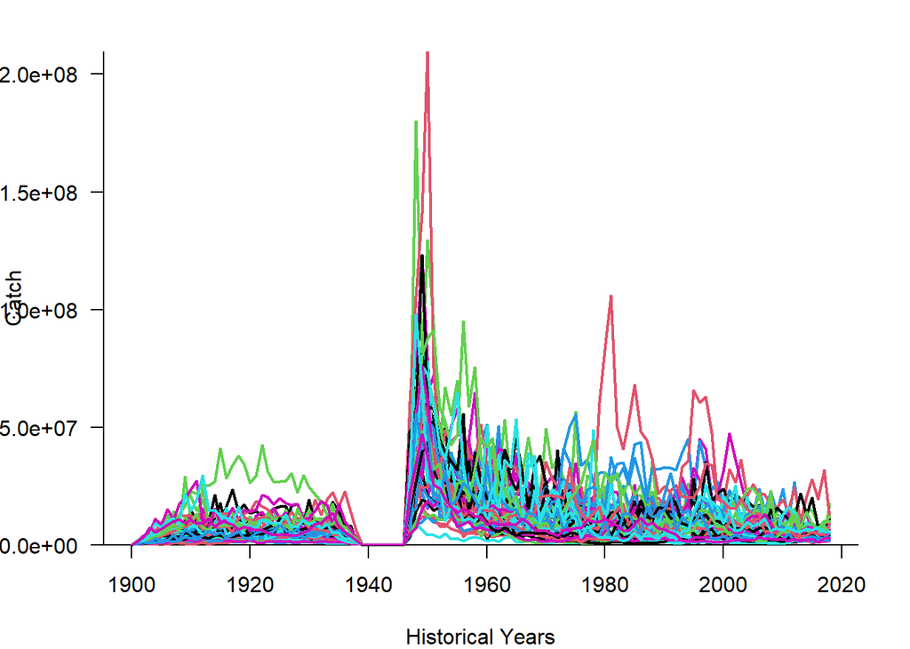

### Historical Fishing Mortality

#### Historical Time-Series

Time-series of historical fishing mortality:

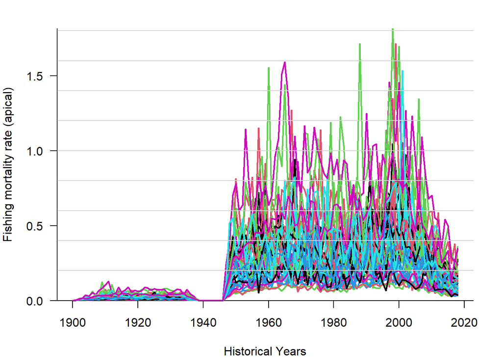

# References

Ally J, Ono DS, Read RB, Wallace M. 1991. Status of major southern California marine sport fish species with management recommendations, based on analyses of catch and size composition data collected on board commercial passenger fishing vessels from 1985 through 1987. California Department of Fish and Game. Marine Resources Division Administrative Report 90-2. 376 p.

Bellquist L, Semmens B, Stohs S, Siddall A. 2017. Impacts of recently implemented recreational fisheries regulations on the Commercial Passenger Fishing Vessel fishery for Paralabrax sp. California. Marine Policy 86: 134-143.

Carruthers TR, Punt AE, Walters CJ, MacCall A, McAllister MK, Dick EJ, Cope J. 2014. Evaluating methods for setting catch limits in data-limited fisheries. Fisheries Research 153:48-68.

California Department of Fish and Wildlife. 2019. Barred Sand Bass, Paralabrax nebulifer. Enhanced Status Report.

Erisman BE, Allen LG, Claisse JT, Pondella DJ, Miller EF, Murray JH, Walters C. 2011. The illusion of plenty: hyperstability masks collapses in two recreational fisheries that target fish spawning aggregations. Canadian Journal of Fisheries and Aquatic Sciences 68: 1705-1716.

Eschmeyer WN, Herald ES. 1999. A field guide to Pacific coast fishes: North America. Boston, NY: Houghton Mifflin Company. 210 p.

Hsieh C-h, Reiss C, Watson W, Allen JM, Hunter JR, Lea RN, Rosenblatt RH, Smith PE, Sugihara G. 2005. A comparison of long-term trends and variability in populations of larvae of exploited and unexploited fishes in the Southern California region: A community approach. Progress in Oceanography 67: 160-185.International Fish and Game Association. 2001. Database of IGFA angling records until 2001. Fort Lauderdale, USA.

Jarvis E, Linardich C, Valle C. 2010. Spawning-related movements of barred sand bass, Paralabrax nebulifer, in southern California: interpretations from two decades of historical tag and recapture data. Bulletin of the Southern California Academy of Sciences 109: 123-143.

Jarvis ET, Gliniak HL, Valle CF. 2014. Effects of fishing and the environment on the long-term sustainability of the recreational saltwater bass fishery in southern California. California Department of Fish and Game 100: 234-259.

Love MS, Brooks A, Ally J. 1996a. An analysis of commercial passenger fishing vessel fisheries for kelp bass and barred sand bass in the Southern California Bight. California Fish and Game 82(3): 105-121.

Love MS, Brooks A, Busatto D, Stephens J, Gregory PA. 1996b. Aspects of the life histories of the kelp bass, Paralabrax clathratus, and barred sand bass, P. nebulifer, from the southern California Bight. Fishery Bulletin 94: 472-481.

Love MS, Passarelli JK, eds. 2020. Miller and Lea’s guide to the coastal marine fishes of California. 3556. UCANR Publications. 418 p.

Mason TJ, Lowe CG. 2010. Home range, habitat use, and site fidelity of barred sand bass within a southern California marine protected area. Fisheries Research 106: 93-101.

Mendoza-Carranza M, Rosales-Casian JA. 2002. Feeding ecology of juvenile kelp bass (Paralabrax clathratus) and barred sand bass (P. nebulifer) in Punta Banda Estuary, Baja California, Mexico: Bulletin of the Southern California Academy of Sciences 101: 103-117.

Pauly D. 1980. On the interrelationships between natural mortality, growth parameters, and mean environmental temperature in 175 fish stocks. J Cons Int. Explor Mer. 39: 175–192.

Semmens B, Parnell E. 2014. Mortality and Population Abundance of Three Species of Paralabrax off San Diego, California R/OPCCFRW-3 Jul. 2012-Jun. 2014. Scripps Institution of Oceanography: University of California, San Diego. 69 p.

Stephens Jr JS, Morris P, Pondella D, Koonce T, Jordan G. 1994. Overview of the dynamics of an urban artificial reef fish assemblage at King Harbor, California, USA, 1974–1991: a recruitment driven system. Bulletin of Marine Science 55: 1224-1239.

Teesdale GN, Wolfe BW, Lowe CG. 2015. Patterns of home ranging, site fidelity, and seasonal spawning migration of barred sand bass caught within the Palos Verdes Shelf Superfund Site. Marine Ecology Progress Series 539: 255-269.

Williams CM, Williams JP, Claisse JT, Pondella II DJ, Domeier ML, Zahn LA. 2013. Morphometric relationships of marine fishes common to Central California and the Southern California Bight. Bulletin, Southern California Academy of Sciences 112: 217-227.

Young PH. 1969. The California Partyboat Fishery 1947–1967. Fish Bulletin 145:91.